# PROJECT_update_2

```python
# !pip install itables
# !pip install xgboost
```

```python
import pandas as pd
import numpy as np
import matplotlib.pyplot as plt

from itables import show, init_notebook_mode

import warnings
warnings.filterwarnings('ignore')
```

```python
df = pd.read_csv('/Users/harnainkaursardarni/Desktop/capstone/grow_complete_clean.csv', index_col='local_time')
df.index = pd.DatetimeIndex(df.index)
```

```python
pct_vs = np.array([
    .65,
    .50,
    .02,
    .0015,
    .14,
    .05,
    .0009,
    .01
])
pct_vs.sum() / 2
```

```
0.6862
```

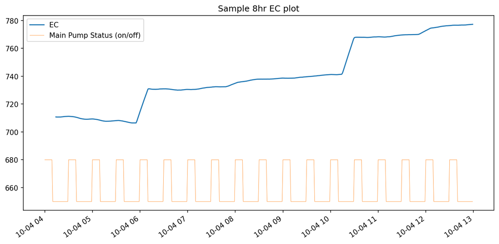

```python
df_plot = df['2023-10-04 04':'2023-10-04 12']

plt.plot(df_plot.EC.rolling(15).mean(), label='EC')
plt.plot((df_plot['Main Pump']*30)+650, lw=.4, zorder=0, label='Main Pump Status (on/off)')
plt.xticks(rotation=35, ha='right')
plt.gcf().set_size_inches(12, 5)
plt.title('Sample 8hr EC plot')
plt.gcf().set_dpi(150)
plt.legend()
plt.show()
```

```python
df.reset_index().drop_duplicates(subset='local_time').set_index('local_time')
```

| local_time | Target - EC | Target - pH | EC | pH | CPU Temperature | Humidity | Room Temp (C) | Water Tank (G) | Water Temp (C) | Auto - Main Pump | ... | Mixing Fans | Air Flow A | Air Flow B | Grow Lights | Mix Pump | Dosing Log | Additive | Volume added (mL) | Pump Speed | minutes_since_last_dose_NM |
| --- | --- | --- | --- | --- | --- | --- | --- | --- | --- | --- | --- | --- | --- | --- | --- | --- | --- | --- | --- | --- | --- |
| 2023-09-30 01:00:00 | NaN | NaN | 688.181818 | 6.524333 | 42.800000 | 63.780000 | NaN | 42.046667 | 20.968421 | off | ... | 0 | 0 | 0 | 0.0 | 1.0 | NaN | NaN | NaN | NaN | 1164.0 |
| 2023-09-30 01:01:00 | NaN | NaN | 687.900000 | 6.527136 | 43.004545 | 63.859091 | NaN | 42.204545 | 20.937273 | off | ... | 0 | 0 | 0 | 0.0 | 1.0 | NaN | NaN | NaN | NaN | 1165.0 |
| 2023-09-30 01:02:00 | NaN | NaN | 687.236364 | 6.523818 | 43.436364 | 63.959091 | 21.942105 | 41.872727 | 20.950909 | off | ... | 0 | 0 | 0 | 0.0 | 1.0 | NaN | NaN | NaN | NaN | 1166.0 |
| 2023-09-30 01:03:00 | NaN | NaN | 688.090909 | 6.530182 | 43.618182 | 64.195455 | 21.900000 | 42.495455 | 20.970000 | off | ... | 0 | 0 | 0 | 0.0 | 1.0 | NaN | NaN | NaN | NaN | 1167.0 |
| 2023-09-30 01:04:00 | NaN | NaN | 688.478261 | 6.526435 | 43.495652 | 64.204348 | 21.865217 | 41.978261 | 20.968696 | off | ... | 0 | 0 | 0 | 0.0 | 1.0 | NaN | NaN | NaN | NaN | 1168.0 |
| ... | ... | ... | ... | ... | ... | ... | ... | ... | ... | ... | ... | ... | ... | ... | ... | ... | ... | ... | ... | ... | ... |
| 2023-12-10 22:02:00 | NaN | NaN | 432.421739 | 6.531043 | 38.656522 | 56.139130 | 17.643478 | 42.747826 | 17.026087 | NaN | ... | 0 | 1 | 1 | 0.0 | 1.0 | NaN | NaN | NaN | NaN | 942.0 |
| 2023-12-10 22:03:00 | NaN | NaN | 432.708333 | 6.527125 | 38.900000 | 56.625000 | 17.662500 | 43.700000 | 17.017500 | NaN | ... | 0 | 1 | 1 | 0.0 | 1.0 | NaN | NaN | NaN | NaN | 943.0 |
| 2023-12-10 22:04:00 | NaN | NaN | 432.471429 | 6.525762 | 38.600000 | 56.833333 | 17.700000 | 43.157143 | 17.011429 | NaN | ... | 0 | 1 | 1 | 0.0 | 1.0 | NaN | NaN | NaN | NaN | 944.0 |
| 2023-12-10 22:05:00 | NaN | NaN | 432.444444 | 6.532519 | 38.233333 | 56.955556 | 17.744444 | 43.688889 | 16.997778 | NaN | ... | 0 | 1 | 1 | 0.0 | 1.0 | NaN | NaN | NaN | NaN | 945.0 |
| 2023-12-10 22:06:00 | NaN | NaN | 432.392857 | 6.531357 | 38.900000 | 57.050000 | 17.742857 | 42.428571 | 16.982857 | NaN | ... | 0 | 1 | 1 | 0.0 | 1.0 | NaN | NaN | NaN | NaN | 946.0 |

84604 rows × 27 columns

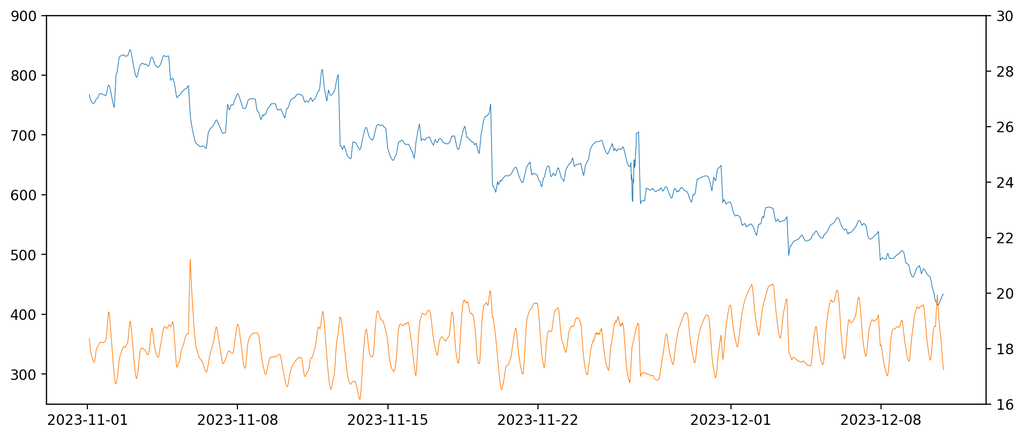

```python
df_plot = df['2023-11':]
window = 120

fig, ax1 = plt.subplots(figsize=(12, 5), dpi=200)
ax1.plot(df_plot.EC.rolling(window).mean(), label='EC', lw=.5)
ax1.set_ylim(250, 900)

ax2 = ax1.twinx()
ax2.plot(df_plot['Water Temp (C)'].rolling(window).mean(), label='Water Temp (C)', lw=.5, color='C1')
ax2.set_ylim(16, 30)
plt.xticks(rotation=35, ha='right')
plt.show()
```

```python
pd.crosstab(df_plot.Additive, df['Volume added (mL)'])
```

| Volume added (mL) Additive | 5.0 | 10.0 | 15.0 |
| --- | --- | --- | --- |
| Nutrient Mix | 0 | 12 | 29 |
| pH Down | 54 | 0 | 0 |
| pH Up | 153 | 0 | 0 |

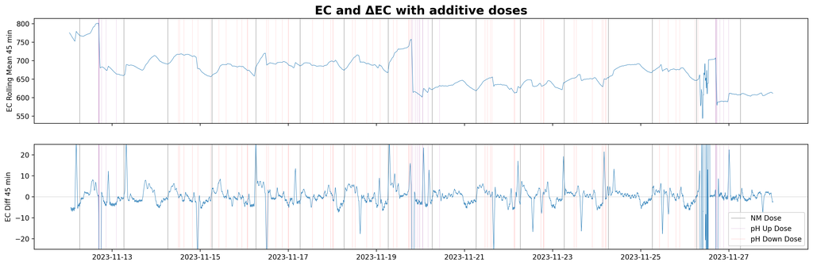

```python
df_plot = df['2023-11-12':'2023-11-27']
window = 45
diff = 45

fig, axs = plt.subplots(nrows=2, figsize=(20, 6), dpi=200, sharex=True)
ax = axs[0]
ax.plot(df_plot.EC.rolling(window).mean(), label='EC', lw=.5, zorder=2)
[ax.axvline(x, color='gray', lw=.5, zorder=1) for x in df_plot.index[df_plot.Additive=='Nutrient Mix']]
[ax.axvline(x, color='purple', lw=.1, zorder=0) for x in df_plot.index[df_plot.Additive=='pH Down']]
[ax.axvline(x, color='red', lw=.1, zorder=0, alpha=.75) for x in df_plot.index[df_plot.Additive=='pH Up']]
ax.set_ylabel(f'EC Rolling Mean {window} min')
ax.set_title('EC and \u0394EC with additive doses', fontweight='bold', size='xx-large')

ax = axs[1]
ax.plot(df_plot.EC.diff(diff).rolling(45).mean(), lw=.5, zorder=2)
ax.set_ylim(-25, 25)

NM_label_list = np.empty(200, dtype='O')
NM_label_list[0] = 'NM Dose'

pHU_label_list = np.empty(200, dtype='O')
pHU_label_list[0] = 'pH Up Dose'

pHD_label_list = np.empty(200, dtype='O')
pHD_label_list[0] = 'pH Down Dose'

[ax.axvline(x, color='gray', lw=.5, zorder=1, label=NM_label_list[i]) for i, x in enumerate(df_plot.index[df_plot.Additive=='Nutrient Mix'])]
[ax.axvline(x, color='purple', lw=.1, zorder=0, label=pHU_label_list[i]) for i, x in enumerate(df_plot.index[df_plot.Additive=='pH Down'])]
[ax.axvline(x, color='red', lw=.1, zorder=0, label=pHD_label_list[i]) for i, x in enumerate(df_plot.index[df_plot.Additive=='pH Up'])]
ax.axhline(y=0, color='black', lw=.1, zorder=0)
ax.set_ylabel(f'EC Diff {diff} min')
plt.legend()
plt.show()
```

#### -------------HARNAIN

```python
model = pd.read_csv('/Users/harnainkaursardarni/Desktop/capstone/model_input_data.csv', index_col='local_time')
```

```python
model
```

| local_time | EC | pH | Humidity | Room Temp (C) | Water Tank (G) | Water Temp (C) | Air Pump | Main Pump | Mixing Fans | Air Flow A | Air Flow B | Grow Lights | Mix Pump | minutes_since_last_dose_NM | Water Tank (L) | Nutrient Mix | pH Down | pH Up | TARGET - NM Concentration (%) |
| --- | --- | --- | --- | --- | --- | --- | --- | --- | --- | --- | --- | --- | --- | --- | --- | --- | --- | --- | --- |
| 2023-11-12 00:00:00 | 779.814815 | 6.506741 | 62.822222 | 19.162963 | 37.581481 | 18.961111 | 1 | 1 | 1 | 1 | 1 | 0.0 | 1.0 | 244.0 | 142.261316 | NaN | NaN | NaN | 0.007029 |
| 2023-11-12 00:01:00 | 778.660000 | 6.502480 | 61.632000 | 19.064000 | 36.844000 | 18.910000 | 1 | 1 | 0 | 1 | 1 | 0.0 | 1.0 | 245.0 | 139.469646 | NaN | NaN | NaN | 0.007165 |
| 2023-11-12 00:02:00 | 777.929630 | 6.502815 | 61.603704 | 19.096296 | 35.944444 | 18.841111 | 1 | 1 | 0 | 1 | 1 | 0.0 | 1.0 | 246.0 | 136.064459 | NaN | NaN | NaN | 0.007339 |
| 2023-11-12 00:03:00 | 778.038889 | 6.496222 | 62.077778 | 19.055556 | 35.677778 | 18.810000 | 1 | 1 | 0 | 1 | 1 | 0.0 | 1.0 | 247.0 | 135.055017 | NaN | NaN | NaN | 0.007389 |
| 2023-11-12 00:04:00 | 777.604348 | 6.502783 | 62.226087 | 19.121739 | 35.313043 | 18.799565 | 1 | 1 | 0 | 1 | 1 | 0.0 | 1.0 | 248.0 | 133.674348 | NaN | NaN | NaN | 0.007460 |
| ... | ... | ... | ... | ... | ... | ... | ... | ... | ... | ... | ... | ... | ... | ... | ... | ... | ... | ... | ... |
| 2023-12-10 22:02:00 | 432.421739 | 6.531043 | 56.139130 | 17.643478 | 42.747826 | 17.026087 | 1 | 1 | 0 | 1 | 1 | 0.0 | 1.0 | 942.0 | 161.818048 | NaN | NaN | NaN | 0.004626 |
| 2023-12-10 22:03:00 | 432.708333 | 6.527125 | 56.625000 | 17.662500 | 43.700000 | 17.017500 | 1 | 1 | 0 | 1 | 1 | 0.0 | 1.0 | 943.0 | 165.422417 | NaN | NaN | NaN | 0.004521 |
| 2023-12-10 22:04:00 | 432.471429 | 6.525762 | 56.833333 | 17.700000 | 43.157143 | 17.011429 | 1 | 1 | 0 | 1 | 1 | 0.0 | 1.0 | 944.0 | 163.367480 | NaN | NaN | NaN | 0.004574 |
| 2023-12-10 22:05:00 | 432.444444 | 6.532519 | 56.955556 | 17.744444 | 43.688889 | 16.997778 | 1 | 1 | 0 | 1 | 1 | 0.0 | 1.0 | 945.0 | 165.380357 | NaN | NaN | NaN | 0.004514 |
| 2023-12-10 22:06:00 | 432.392857 | 6.531357 | 57.050000 | 17.742857 | 42.428571 | 16.982857 | 1 | 1 | 0 | 1 | 1 | 0.0 | 1.0 | 946.0 | 160.609539 | NaN | NaN | NaN | 0.004644 |

41647 rows × 19 columns

```python
model.index = pd.DatetimeIndex(model.index)
```

```python
display(model.head())
display(model.info())
```

| local_time | EC | pH | Humidity | Room Temp (C) | Water Tank (G) | Water Temp (C) | Air Pump | Main Pump | Mixing Fans | Air Flow A | Air Flow B | Grow Lights | Mix Pump | minutes_since_last_dose_NM | Water Tank (L) | Nutrient Mix | pH Down | pH Up | TARGET - NM Concentration (%) |
| --- | --- | --- | --- | --- | --- | --- | --- | --- | --- | --- | --- | --- | --- | --- | --- | --- | --- | --- | --- |
| 2023-11-12 00:00:00 | 779.814815 | 6.506741 | 62.822222 | 19.162963 | 37.581481 | 18.961111 | 1 | 1 | 1 | 1 | 1 | 0.0 | 1.0 | 244.0 | 142.261316 | NaN | NaN | NaN | 0.007029 |
| 2023-11-12 00:01:00 | 778.660000 | 6.502480 | 61.632000 | 19.064000 | 36.844000 | 18.910000 | 1 | 1 | 0 | 1 | 1 | 0.0 | 1.0 | 245.0 | 139.469646 | NaN | NaN | NaN | 0.007165 |
| 2023-11-12 00:02:00 | 777.929630 | 6.502815 | 61.603704 | 19.096296 | 35.944444 | 18.841111 | 1 | 1 | 0 | 1 | 1 | 0.0 | 1.0 | 246.0 | 136.064459 | NaN | NaN | NaN | 0.007339 |
| 2023-11-12 00:03:00 | 778.038889 | 6.496222 | 62.077778 | 19.055556 | 35.677778 | 18.810000 | 1 | 1 | 0 | 1 | 1 | 0.0 | 1.0 | 247.0 | 135.055017 | NaN | NaN | NaN | 0.007389 |
| 2023-11-12 00:04:00 | 777.604348 | 6.502783 | 62.226087 | 19.121739 | 35.313043 | 18.799565 | 1 | 1 | 0 | 1 | 1 | 0.0 | 1.0 | 248.0 | 133.674348 | NaN | NaN | NaN | 0.007460 |

```
<class 'pandas.core.frame.DataFrame'>
DatetimeIndex: 41647 entries, 2023-11-12 00:00:00 to 2023-12-10 22:06:00
Data columns (total 19 columns):
 #   Column                         Non-Null Count  Dtype
---  ------                         --------------  -----
 0   EC                             41647 non-null  float64
 1   pH                             41647 non-null  float64
 2   Humidity                       41647 non-null  float64
 3   Room Temp (C)                  41647 non-null  float64
 4   Water Tank (G)                 41647 non-null  float64
 5   Water Temp (C)                 41647 non-null  float64
 6   Air Pump                       41647 non-null  int64
 7   Main Pump                      41647 non-null  int64
 8   Mixing Fans                    41647 non-null  int64
 9   Air Flow A                     41647 non-null  int64
 10  Air Flow B                     41647 non-null  int64
 11  Grow Lights                    41647 non-null  float64
 12  Mix Pump                       41647 non-null  float64
 13  minutes_since_last_dose_NM     41647 non-null  float64
 14  Water Tank (L)                 41647 non-null  float64
 15  Nutrient Mix                   29 non-null     float64
 16  pH Down                        45 non-null     float64
 17  pH Up                          103 non-null    float64
 18  TARGET - NM Concentration (%)  41647 non-null  float64
dtypes: float64(14), int64(5)
memory usage: 6.4 MB
```

```
None
```

```python
print(model.isnull().sum())
```

```
EC                                   0
pH                                   0
Humidity                             0
Room Temp (C)                        0
Water Tank (G)                       0
Water Temp (C)                       0
Air Pump                             0
Main Pump                            0
Mixing Fans                          0
Air Flow A                           0
Air Flow B                           0
Grow Lights                          0
Mix Pump                             0
minutes_since_last_dose_NM           0
Water Tank (L)                       0
Nutrient Mix                     41618
pH Down                          41602
pH Up                            41544
TARGET - NM Concentration (%)        0
dtype: int64
```

### Feature engineering:

#### Handling missing values:

```python
model_cleaned = model.copy()

# fill in the missing values for numerical columns with mean:
numeric_cols = model_cleaned.select_dtypes(include=['float64', 'int64']).columns
model_cleaned[numeric_cols] = model_cleaned[numeric_cols].fillna(model_cleaned[numeric_cols].mean())

# filling missing values for categorical columns with mode, if at least one non missing value exists:
categorical_cols = model_cleaned.select_dtypes(include=['object']).columns
for col in categorical_cols:
    if model_cleaned[col].notnull().any():  # Check if at least one non-missing value exists
        model_cleaned[col] = model_cleaned[col].fillna(model_cleaned[col].mode().iloc[0])
```

```python
print(model_cleaned.isnull().sum())
```

```
EC                               0
pH                               0
Humidity                         0
Room Temp (C)                    0
Water Tank (G)                   0
Water Temp (C)                   0
Air Pump                         0
Main Pump                        0
Mixing Fans                      0
Air Flow A                       0
Air Flow B                       0
Grow Lights                      0
Mix Pump                         0
minutes_since_last_dose_NM       0
Water Tank (L)                   0
Nutrient Mix                     0
pH Down                          0
pH Up                            0
TARGET - NM Concentration (%)    0
dtype: int64
```

```python
# 1. create a lag feature for the target variable:

model['Target_Lag_1'] = model['TARGET - NM Concentration (%)'].shift(1)
```

```python
# 2. create a rolling window statistics for EC feature:

model['EC_Rolling_Mean'] = model['EC'].rolling(window=5).mean()
```

```python
# 3. create an interaction feature between EC and pH:

model['EC_times_pH'] = model['EC'] * model['pH']
```

```python
model['Year'] = model.index.year
model['Month'] = model.index.month
model['Day'] = model.index.day
model['Hour'] = model.index.hour
model['Minute'] = model.index.minute
```

```python
model.head()
```

| local_time | EC | pH | Humidity | Room Temp (C) | Water Tank (G) | Water Temp (C) | Air Pump | Main Pump | Mixing Fans | Air Flow A | ... | pH Up | TARGET - NM Concentration (%) | Target_Lag_1 | EC_Rolling_Mean | EC_times_pH | Year | Month | Day | Hour | Minute |
| --- | --- | --- | --- | --- | --- | --- | --- | --- | --- | --- | --- | --- | --- | --- | --- | --- | --- | --- | --- | --- | --- |
| 2023-11-12 00:00:00 | 779.814815 | 6.506741 | 62.822222 | 19.162963 | 37.581481 | 18.961111 | 1 | 1 | 1 | 1 | ... | NaN | 0.007029 | NaN | NaN | 5074.052826 | 2023 | 11 | 12 | 0 | 0 |
| 2023-11-12 00:01:00 | 778.660000 | 6.502480 | 61.632000 | 19.064000 | 36.844000 | 18.910000 | 1 | 1 | 0 | 1 | ... | NaN | 0.007165 | 0.007029 | NaN | 5063.221077 | 2023 | 11 | 12 | 0 | 1 |
| 2023-11-12 00:02:00 | 777.929630 | 6.502815 | 61.603704 | 19.096296 | 35.944444 | 18.841111 | 1 | 1 | 0 | 1 | ... | NaN | 0.007339 | 0.007165 | NaN | 5058.732320 | 2023 | 11 | 12 | 0 | 2 |
| 2023-11-12 00:03:00 | 778.038889 | 6.496222 | 62.077778 | 19.055556 | 35.677778 | 18.810000 | 1 | 1 | 0 | 1 | ... | NaN | 0.007389 | 0.007339 | NaN | 5054.313520 | 2023 | 11 | 12 | 0 | 3 |
| 2023-11-12 00:04:00 | 777.604348 | 6.502783 | 62.226087 | 19.121739 | 35.313043 | 18.799565 | 1 | 1 | 0 | 1 | ... | NaN | 0.007460 | 0.007389 | 778.409536 | 5056.592029 | 2023 | 11 | 12 | 0 | 4 |

5 rows × 27 columns

Let's review what has been done:

1. **Handling Missing Values:**
   - filled missing values in numerical columns with the mean of each column using `fillna()`.
   - For categorical columns, filled missing values with the mode using a loop.
2. **Feature Engineering:**
   - Created a lag feature for the target variable "TARGET - NM Concentration (%)" called "Target_Lag_1" by shifting the target variable by one time step.
   - Calculated the rolling mean for the "EC" feature with a window size of 5 and created a new feature named "EC_Rolling_Mean".
   - Created an interaction feature between "EC" and "pH" called "EC_times_pH" by multiplying the "EC" and "pH" columns.
   - Extracted time-based features such as year, month, day, hour, and minute from the index and added them as new columns to the DataFrame.

Now, lets proceed with selecting the necessary columns for model training. Based on the target variable and the features engineered:

- **Target Variable:** "TARGET - NM Concentration (%)"
- **Input Features:** 'EC', 'pH', 'Humidity', 'Room Temp (C)', 'Water Tank (G)', 'Water Temp (C)', 'Air Pump', 'Main Pump', 'Mixing Fans', 'Air Flow A', 'Air Flow B', 'Grow Lights', 'Mix Pump', 'minutes_since_last_dose_NM', 'Water Tank (L)', 'Nutrient Mix', 'pH Down', 'pH Up'

## Modelling:

- using models like linear regression, Gradient boosting, ANN to see which performs better

```python
model.columns
```

```
Index(['EC', 'pH', 'Humidity', 'Room Temp (C)', 'Water Tank (G)',
       'Water Temp (C)', 'Air Pump', 'Main Pump', 'Mixing Fans', 'Air Flow A',
       'Air Flow B', 'Grow Lights', 'Mix Pump', 'minutes_since_last_dose_NM',
       'Water Tank (L)', 'Nutrient Mix', 'pH Down', 'pH Up',
       'TARGET - NM Concentration (%)', 'Target_Lag_1', 'EC_Rolling_Mean',
       'EC_times_pH', 'Year', 'Month', 'Day', 'Hour', 'Minute'],
      dtype='object')
```

```python
# lets, define features (X) and target variable (y)

features = ['EC', 'pH', 'Humidity', 'Room Temp (C)', 'Water Tank (G)', 'Water Temp (C)',
            'Air Pump', 'Main Pump', 'Mixing Fans', 'Air Flow A', 'Air Flow B', 'Grow Lights',
            'Mix Pump', 'minutes_since_last_dose_NM', 'Water Tank (L)', 'Nutrient Mix',
            'pH Down', 'pH Up']
target = 'TARGET - NM Concentration (%)'

X = model_cleaned[features]
y = model_cleaned[target]
```

### 1. Linear regression:

```python
from sklearn.model_selection import train_test_split
from sklearn.linear_model import LinearRegression
from sklearn.metrics import mean_squared_error

X_train, X_test, y_train, y_test = train_test_split(X, y, test_size=0.2, shuffle=False)
```

```python
linear_reg = LinearRegression()
linear_reg.fit(X_train, y_train)
```

```
LinearRegression()
```

```python
y_pred_linear_reg = linear_reg.predict(X_test)

rmse_linear_reg = mean_squared_error(y_test, y_pred_linear_reg, squared=False)
print("Linear Regression RMSE:", rmse_linear_reg)
```

```
Linear Regression RMSE: 0.0002025757547183833
```

### 2. Gradient boosting model:

```python
from sklearn.ensemble import GradientBoostingRegressor

gradient_boosting = GradientBoostingRegressor()
gradient_boosting.fit(X_train, y_train)
```

```
GradientBoostingRegressor()
```

```python
y_pred_gradient_boosting = gradient_boosting.predict(X_test)

rmse_gradient_boosting = mean_squared_error(y_test, y_pred_gradient_boosting, squared=False)
print("Gradient Boosting RMSE:", rmse_gradient_boosting)
```

```
Gradient Boosting RMSE: 9.697918011420878e-05
```

### 3. Artifical neural networks(ANN):

```python
from sklearn.neural_network import MLPRegressor

ann = MLPRegressor(max_iter=500)
ann.fit(X_train, y_train)
```

```
MLPRegressor(max_iter=500)
```

```python
y_pred_ann = ann.predict(X_test)

rmse_ann = mean_squared_error(y_test, y_pred_ann, squared=False)
print("Artificial Neural Network RMSE:", rmse_ann)
```

```
Artificial Neural Network RMSE: 0.5154275947010003
```

Based on the RMSE values, the Gradient Boosting model performed the best.

### Evaluation:

- lets, evaluate the performance of the models using cross validation with TimeSeriesSplit and then proceed with hyperparameter tuning for the gradient boosting model.

```python
from sklearn.model_selection import TimeSeriesSplit, cross_val_score

tscv = TimeSeriesSplit(n_splits=5)
```

```python
def cross_val_rmse(model, X, y):
    rmse_scores = cross_val_score(model, X, y, cv=tscv, scoring='neg_root_mean_squared_error')
    return -rmse_scores

linear_reg_cv_rmse = cross_val_rmse(linear_reg, X, y)
gradient_boosting_cv_rmse = cross_val_rmse(gradient_boosting, X, y)
ann_cv_rmse = cross_val_rmse(ann, X, y)

print("Linear Regression CV RMSE:", linear_reg_cv_rmse)
print("Gradient Boosting CV RMSE:", gradient_boosting_cv_rmse)
print("ANN CV RMSE:", ann_cv_rmse)
```

```
Linear Regression CV RMSE: [0.00038089 0.000271   0.00021762 0.00025579 0.00018315]
Gradient Boosting CV RMSE: [2.78015085e-04 1.85498161e-04 1.14472840e-04 7.58073305e-05
 8.48914940e-05]
ANN CV RMSE: [0.5376978  0.23145636 0.35041651 0.89811061 0.69586389]
```

```python
# hyperparameter tuning:

from sklearn.model_selection import GridSearchCV

param_grid = {
    'n_estimators': [50, 100],
    'max_depth': [3, 5],
    'learning_rate': [0.1, 0.01]
}
```

```python
tscv = TimeSeriesSplit(n_splits=3)

grid_search = GridSearchCV(gradient_boosting, param_grid, cv=tscv, scoring='neg_root_mean_squared_error', verbose=1, n_jobs=-1)
grid_search.fit(X, y)
print("Best Parameters:", grid_search.best_params_)
print("Best RMSE:", -grid_search.best_score_)
```

```
Fitting 3 folds for each of 8 candidates, totalling 24 fits
Best Parameters: {'learning_rate': 0.1, 'max_depth': 5, 'n_estimators': 100}
Best RMSE: 0.00010083929808762843
```

## Model interpretation:

- let's start by analyzing the feature importances for the Gradient Boosting model and coefficients for the Linear Regression model.

### 1. Gradient Boosting

```python
importances = gradient_boosting.feature_importances_
feature_names = X.columns
indices = np.argsort(importances)[::-1]
sorted_feature_names = [feature_names[i] for i in indices]
```

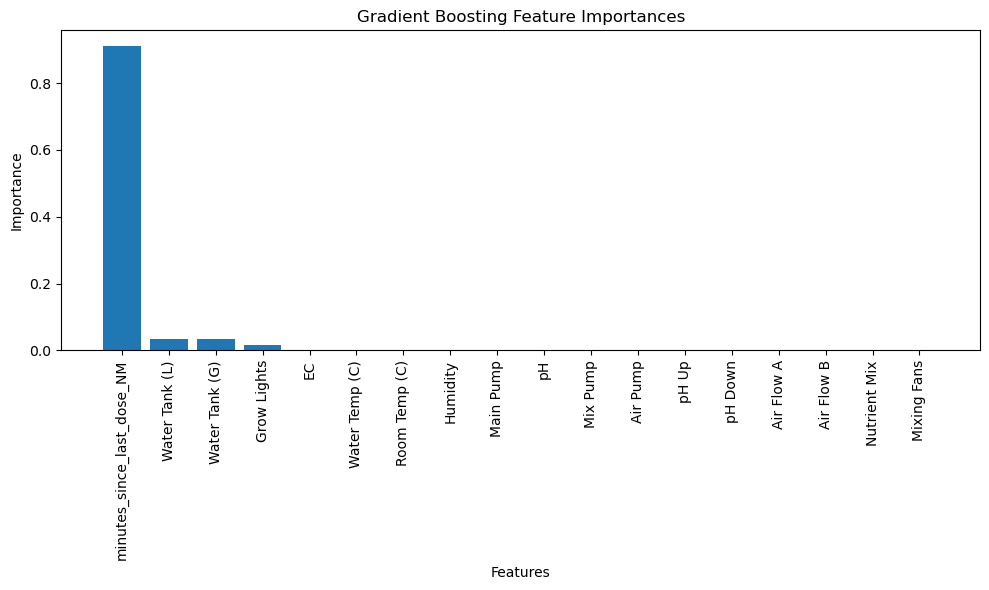

```python
plt.figure(figsize=(10, 6))
plt.title("Gradient Boosting Feature Importances")
plt.bar(range(X.shape[1]), importances[indices], align="center")
plt.xticks(range(X.shape[1]), sorted_feature_names, rotation=90)
plt.xlabel("Features")
plt.ylabel("Importance")
plt.tight_layout()
plt.show()
```

### 2. linear regression:

```python
coefficients = linear_reg.coef_
indices = np.argsort(np.abs(coefficients))[::-1]
sorted_feature_names = [feature_names[i] for i in indices]
```

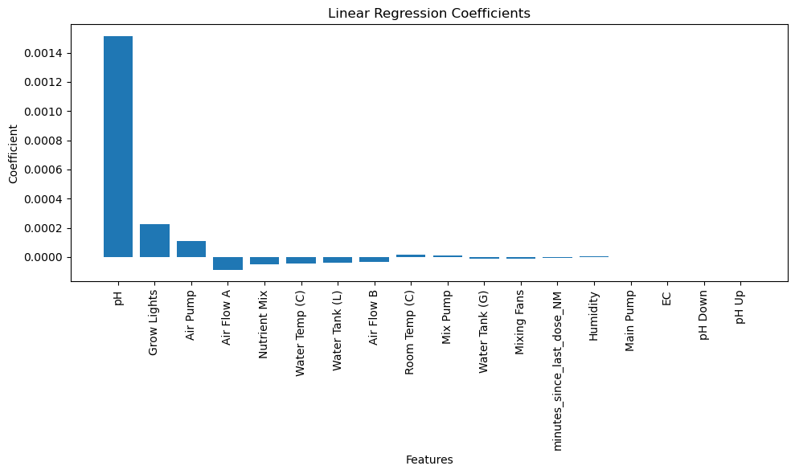

```python
plt.figure(figsize=(10, 6))
plt.title("Linear Regression Coefficients")
plt.bar(range(X.shape[1]), coefficients[indices], align="center")
plt.xticks(range(X.shape[1]), sorted_feature_names, rotation=90)
plt.xlabel("Features")
plt.ylabel("Coefficient")
plt.tight_layout()
plt.show()
```

Interpreting the feature importances and coefficients:

1. **Gradient Boosting Model:**
   - The feature importance plot indicates that **minutes_since_last_dose_NM** has the highest importance among all features. This suggests that the time elapsed since the last nutrient mix dose has the most significant impact on the predicted target variable (*TARGET - NM Concentration (%)*) according to the Gradient Boosting model.
2. **Linear Regression Model:**
   - The coefficient plot shows that **pH** has the highest absolute coefficient value among all features. This implies that pH has the strongest linear relationship with the target variable in the Linear Regression model. A higher positive coefficient suggests a positive correlation between pH and the target variable.

## Model comparison:

```python
from sklearn.metrics import r2_score, mean_absolute_error

def evaluate_model(model, X_test, y_test):
    y_pred = model.predict(X_test)
    r2 = r2_score(y_test, y_pred)
    mae = mean_absolute_error(y_test, y_pred)
    n = len(y_test)
    k = X_test.shape[1]
    adj_r2 = 1 - (1 - r2) * ((n - 1) / (n - k - 1))
    return r2, mae, adj_r2
```

```python
r2_lr, mae_lr, adj_r2_lr = evaluate_model(linear_reg, X_test, y_test)
r2_gb, mae_gb, adj_r2_gb = evaluate_model(gradient_boosting, X_test, y_test)
r2_ann, mae_ann, adj_r2_ann = evaluate_model(ann, X_test, y_test)
```

```python
# lets, display the evaluation metrics:

print("Linear Regression:")
print(f"R-squared: {r2_lr}")
print(f"MAE: {mae_lr}")
print(f"Adjusted R-squared: {adj_r2_lr}\n")

print("Gradient Boosting:")
print(f"R-squared: {r2_gb}")
print(f"MAE: {mae_gb}")
print(f"Adjusted R-squared: {adj_r2_gb}\n")

print("Artificial Neural Network:")
print(f"R-squared: {r2_ann}")
print(f"MAE: {mae_ann}")
print(f"Adjusted R-squared: {adj_r2_ann}")
```

```
Linear Regression:
R-squared: 0.9884370311486875
MAE: 0.00017358811584377158
Adjusted R-squared: 0.9884119880203849

Gradient Boosting:
R-squared: 0.997349966031215
MAE: 6.449761107781842e-05
Adjusted R-squared: 0.9973442265761027

Artificial Neural Network:
R-squared: -74855.54118873739
MAE: 0.23388846096001362
Adjusted R-squared: -75017.66581169459
```

#### Based on the above metrics, we can say that the:

- Gradient Boosting outperforms Linear Regression and ANN, with the highest R-squared and lowest MAE.
- Linear Regression also performs well, but is slightly worse than Gradient Boosting.
- The Artificial Neural network performs significantly worse compared to the other models, as indicated by the extremely low Rsquared and high MAE.

Hence, Gradient Boosting appears to be the most effective model for predicting the target variable.

# ROUND 2

```python
# Now, lets refine the models by selecting only the most important features: Selecting only features with non trivial importance

feature_importance = pd.DataFrame({'feature': X.columns, 'importance': gradient_boosting.feature_importances_})
threshold = 0.05

important_features = feature_importance[feature_importance['importance'] > threshold]['feature']
X_train_selected = X_train[important_features]
X_test_selected = X_test[important_features]
```

```python
gb_regressor_selected = GradientBoostingRegressor()
gb_regressor_selected.fit(X_train_selected, y_train)
```

```
GradientBoostingRegressor()
```

```python
lr_regressor_selected = LinearRegression()
lr_regressor_selected.fit(X_train_selected, y_train)
```

```
LinearRegression()
```

```python
def evaluate_model_performance(model, X_test, y_test):
    y_pred = model.predict(X_test)
    rmse = mean_squared_error(y_test, y_pred, squared=False)
    r2 = r2_score(y_test, y_pred)
    mae = mean_absolute_error(y_test, y_pred)
    return rmse, r2, mae
```

```python
# Gradient Boosting model:

gb_rmse, gb_r2, gb_mae = evaluate_model_performance(gb_regressor_selected, X_test_selected, y_test)
print("Gradient Boosting Model:")
print(f"RMSE: {gb_rmse}")
print(f"R-squared: {gb_r2}")
print(f"MAE: {gb_mae}\n")
```

```
Gradient Boosting Model:
RMSE: 0.00048200340159611536
R-squared: 0.9345371919103007
MAE: 0.00038845732882384883
```

```python
# Linear Regression model:

lr_rmse, lr_r2, lr_mae = evaluate_model_performance(lr_regressor_selected, X_test_selected, y_test)
print("Linear Regression Model:")
print(f"RMSE: {lr_rmse}")
print(f"R-squared: {lr_r2}")
print(f"MAE: {lr_mae}")
```

```
Linear Regression Model:
RMSE: 0.0004913571537061275
R-squared: 0.9319717982122547
MAE: 0.00039344735825242946
```

### Refinement of Models

Now that we refined the models by selecting only the most important features and retrained them, here are the evaluation metrics for the Gradient Boosting and Linear Regression models after refinement:

**Gradient Boosting Model**:

- RMSE: 0.000482
- R-squared: 0.935
- MAE: 0.000388

**Linear Regression Model**:

- RMSE: 0.000491
- R-squared: 0.932
- MAE: 0.000393

Both models are showing decent performances, based on the above metrics, we can say that the Gradient Boosting model is slightly outperforming the Linear Regression model.

### Implementing a Recurrent Neural Network for time series data:

```python
import numpy as np
import tensorflow as tf
from sklearn.model_selection import train_test_split
from sklearn.preprocessing import StandardScaler

# lets reshape the data for RNN:

X_train = np.reshape(X_train.values, (X_train.shape[0], X_train.shape[1], 1))
X_test = np.reshape(X_test.values, (X_test.shape[0], X_test.shape[1], 1))
```

```python
scaler = StandardScaler()
X_train_scaled = scaler.fit_transform(X_train.reshape(-1, X_train.shape[-1])).reshape(X_train.shape)
X_test_scaled = scaler.transform(X_test.reshape(-1, X_test.shape[-1])).reshape(X_test.shape)
```

```python
model = tf.keras.Sequential([
    tf.keras.layers.SimpleRNN(units=64, input_shape=(X_train.shape[1], X_train.shape[2])),
    tf.keras.layers.Dense(units=1)
])

model.compile(optimizer='adam', loss='mse')
```

```python
history = model.fit(X_train_scaled, y_train, epochs=10, batch_size=32, validation_split=0.1)
```

```
938/938 ━━━━━━━━━━━━━━━━━━━━ 2s 1ms/step - loss: 0.0022 - val_loss: 3.3165e-06
938/938 ━━━━━━━━━━━━━━━━━━━━ 1s 1ms/step - loss: 4.0184e-06 - val_loss: 7.8384e-06
938/938 ━━━━━━━━━━━━━━━━━━━━ 1s 1ms/step - loss: 1.6823e-05 - val_loss: 3.3854e-06
938/938 ━━━━━━━━━━━━━━━━━━━━ 1s 1ms/step - loss: 2.6837e-05 - val_loss: 1.2449e-04
938/938 ━━━━━━━━━━━━━━━━━━━━ 1s 1ms/step - loss: 2.1212e-05 - val_loss: 1.4747e-05
938/938 ━━━━━━━━━━━━━━━━━━━━ 1s 1ms/step - loss: 1.8472e-05 - val_loss: 2.9114e-05
938/938 ━━━━━━━━━━━━━━━━━━━━ 1s 1ms/step - loss: 7.1811e-06 - val_loss: 1.0515e-05
938/938 ━━━━━━━━━━━━━━━━━━━━ 1s 1ms/step - loss: 1.2191e-05 - val_loss: 1.3695e-05
938/938 ━━━━━━━━━━━━━━━━━━━━ 1s 1ms/step - loss: 1.5637e-06 - val_loss: 3.2286e-06
938/938 ━━━━━━━━━━━━━━━━━━━━ 1s 1ms/step - loss: 1.0908e-05 - val_loss: 5.1522e-07
```

```python
mse = model.evaluate(X_test_scaled, y_test)
print("Test MSE:", mse)
```

```
261/261 ━━━━━━━━━━━━━━━━━━━━ 0s 437us/step - loss: 4.0629e-07
Test MSE: 6.173489168759261e-07
```

The model seems to be performing reasonably well, with a test MSE of approximately **6.17e-07**, indicating a good predictive performance.

```python
import numpy as np
import tensorflow as tf
from sklearn.model_selection import train_test_split
from sklearn.preprocessing import StandardScaler

X_train = np.reshape(X_train, (X_train.shape[0], X_train.shape[1], 1))
X_test = np.reshape(X_test, (X_test.shape[0], X_test.shape[1], 1))
```

```python
scaler = StandardScaler()
X_train_scaled = scaler.fit_transform(X_train.reshape(-1, X_train.shape[-1])).reshape(X_train.shape)
X_test_scaled = scaler.transform(X_test.reshape(-1, X_test.shape[-1])).reshape(X_test.shape)
```

```python
model = tf.keras.Sequential([
    tf.keras.layers.SimpleRNN(units=64, input_shape=(X_train.shape[1], X_train.shape[2])),
    tf.keras.layers.Dense(units=1)
])

model.compile(optimizer='adam', loss='mse')
```

```python
history = model.fit(X_train_scaled, y_train, epochs=10, batch_size=32, validation_split=0.1)
```

```
938/938 ━━━━━━━━━━━━━━━━━━━━ 2s 1ms/step - loss: 0.0061 - val_loss: 4.4991e-06
938/938 ━━━━━━━━━━━━━━━━━━━━ 1s 1ms/step - loss: 3.9816e-06 - val_loss: 1.0532e-05
938/938 ━━━━━━━━━━━━━━━━━━━━ 1s 1ms/step - loss: 6.3714e-06 - val_loss: 4.7377e-04
938/938 ━━━━━━━━━━━━━━━━━━━━ 1s 1ms/step - loss: 4.5700e-05 - val_loss: 4.3954e-04
938/938 ━━━━━━━━━━━━━━━━━━━━ 1s 1ms/step - loss: 6.5776e-05 - val_loss: 1.8888e-05
938/938 ━━━━━━━━━━━━━━━━━━━━ 1s 1ms/step - loss: 1.4704e-05 - val_loss: 1.8872e-06
938/938 ━━━━━━━━━━━━━━━━━━━━ 1s 1ms/step - loss: 1.5763e-05 - val_loss: 1.4384e-06
938/938 ━━━━━━━━━━━━━━━━━━━━ 1s 1ms/step - loss: 1.6372e-05 - val_loss: 2.3449e-07
938/938 ━━━━━━━━━━━━━━━━━━━━ 1s 1ms/step - loss: 4.3450e-05 - val_loss: 3.9533e-07
938/938 ━━━━━━━━━━━━━━━━━━━━ 1s 1ms/step - loss: 4.4559e-07 - val_loss: 6.9922e-05
```

```python
mse = model.evaluate(X_test_scaled, y_test)
print("Test MSE:", mse)
```

```
261/261 ━━━━━━━━━━━━━━━━━━━━ 0s 438us/step - loss: 8.0814e-05
Test MSE: 7.918237679405138e-05
```

### Recurrent Neural Network implementation:

**RNN Model**:

- The RNN model seems to be performing reasonably well, with a test MSE of approximately **7.92e-05**, indicating that their is a good predictive performance going on.

# Conclusion:

With these advancements, we anticipate a tangible impact on indoor farming practices. The developed model not only facilitates dynamic adjustment of nutrient dosing for optimal plant growth and productivity but also offers valuable insights into nutrient uptake dynamics, thereby contributing to the evolution of autonomous farming technology. Moving forward, the implementation of this solution holds the potential to revolutionize sustainable agricultural practices in indoor farming environments, by enhancing efficiency, productivity, and ultimately fostering a more sustainable future for food production.